# Homework One Solutions

Biostatistics 735 — Machine Learning in Public Health

Published

August 18, 2026

# 1 Solutions

**Exercise 1.** Read `framingham.csv` using `read_csv()`. The dataset uses blank cells for missing values, which `read_csv()` handles automatically.After reading in:

1. Use `str()` to check column types. Which variables are stored as `<dbl>` but should be factors?

```r
library(tidyverse)
library(this.path)

this.dir <- this.dir()
setwd(this.dir)

framingham <- read_csv("framingham.csv")
str(framingham)
```

```
spc_tbl_ [4,240 × 16] (S3: spec_tbl_df/tbl_df/tbl/data.frame)
 $ male           : num [1:4240] 1 0 1 0 0 0 0 0 1 1 ...
 $ age            : num [1:4240] 39 46 48 61 46 43 63 45 52 43 ...
 $ education      : num [1:4240] 4 2 1 3 3 2 1 2 1 1 ...
 $ currentSmoker  : num [1:4240] 0 0 1 1 1 0 0 1 0 1 ...
 $ cigsPerDay     : num [1:4240] 0 0 20 30 23 0 0 20 0 30 ...
 $ BPMeds         : num [1:4240] 0 0 0 0 0 0 0 0 0 0 ...
 $ prevalentStroke: num [1:4240] 0 0 0 0 0 0 0 0 0 0 ...
 $ prevalentHyp   : num [1:4240] 0 0 0 1 0 1 0 0 1 1 ...
 $ diabetes       : num [1:4240] 0 0 0 0 0 0 0 0 0 0 ...
 $ totChol        : num [1:4240] 195 250 245 225 285 228 205 313 260 225 ...
 $ sysBP          : num [1:4240] 106 121 128 150 130 ...
 $ diaBP          : num [1:4240] 70 81 80 95 84 110 71 71 89 107 ...
 $ BMI            : num [1:4240] 27 28.7 25.3 28.6 23.1 ...
 $ heartRate      : num [1:4240] 80 95 75 65 85 77 60 79 76 93 ...
 $ glucose        : num [1:4240] 77 76 70 103 85 99 85 78 79 88 ...
 $ TenYearCHD     : num [1:4240] 0 0 0 1 0 0 1 0 0 0 ...
 - attr(*, "spec")=
  .. cols(
  ..   male = col_double(),
  ..   age = col_double(),
  ..   education = col_double(),
  ..   currentSmoker = col_double(),
  ..   cigsPerDay = col_double(),
  ..   BPMeds = col_double(),
  ..   prevalentStroke = col_double(),
  ..   prevalentHyp = col_double(),
  ..   diabetes = col_double(),
  ..   totChol = col_double(),
  ..   sysBP = col_double(),
  ..   diaBP = col_double(),
  ..   BMI = col_double(),
  ..   heartRate = col_double(),
  ..   glucose = col_double(),
  ..   TenYearCHD = col_double()
  .. )
 - attr(*, "problems")=<externalptr>
```

The variables `male`, `currentSmoker`, `BPMeds`, `prevalentStroke`, `prevalentHyp`, `diabetes`, `TenYearCHD`, and `education` should all be factors.

2. Convert at least four binary or categorical variables to factors with meaningful labels using `mutate()` and `factor()`.

```r
framingham <- framingham |>
  mutate(
    male            = factor(male,            levels = c(0, 1),
                                              labels = c("Female", "Male")),
    currentSmoker   = factor(currentSmoker,   levels = c(0, 1),
                                              labels = c("Non-smoker", "Smoker")),
    BPMeds          = factor(BPMeds,          levels = c(0, 1),
                                              labels = c("No", "Yes")),
    prevalentStroke = factor(prevalentStroke, levels = c(0, 1),
                                              labels = c("No", "Yes")),
    prevalentHyp    = factor(prevalentHyp,    levels = c(0, 1),
                                              labels = c("No", "Yes")),
    diabetes        = factor(diabetes,        levels = c(0, 1),
                                              labels = c("No", "Yes")),
    TenYearCHD      = factor(TenYearCHD,      levels = c(0, 1),
                                              labels = c("No", "Yes")),
    education       = factor(education,       levels = 1:4,
                                              labels = c("Some HS", "HS Diploma",
                                                         "Some College",
                                                         "College Degree"))
  )
```

3. Write the cleaned dataset to a new file called `framingham_clean.csv` using `write_csv()`.

```r
write_csv(framingham, "framingham_clean.csv")
```

**Exercise 2.** Build a single pipeline that:

1. Keeps only participants aged 40–65
2. Creates a new variable `hyp_smoker`: `"Yes"` if the participant has prevalent hypertension **and** is a current smoker, `"No"` otherwise (use `if_else()` or `case_when()`)
3. Computes, for each combination of `hyp_smoker` and `male`: number of participants, mean systolic BP, and 10-year CHD rate
4. Keeps only groups with at least 50 participants
5. Sorts by CHD rate descending

What combination of characteristics is associated with the highest CHD risk in this age group?

```r
framingham |>
  filter(age >= 40, age <= 65) |>
  mutate(
    hyp_smoker = if_else(
      prevalentHyp == "Yes" & currentSmoker == "Smoker",
      "Yes", "No"
    )
  ) |>
  group_by(hyp_smoker, male) |>
  summarize(
    n         = n(),
    mean_sysBP = mean(sysBP,  na.rm = TRUE),
    chd_pct   = mean(TenYearCHD == "Yes", na.rm = TRUE) * 100,
    .groups   = "drop"
  ) |>
  filter(n >= 50) |>
  arrange(desc(chd_pct))
```

```
# A tibble: 4 × 5
  hyp_smoker male       n mean_sysBP chd_pct
  <chr>      <fct>  <int>      <dbl>   <dbl>
1 Yes        Male     290       151.    31.4
2 Yes        Female   201       158.    18.4
3 No         Male    1231       128.    17.5
4 No         Female  1852       132.    12.7
```

Among adults aged 40–65, males with both prevalent hypertension and current smoking (`hyp_smoker == "Yes"`, `male == "Male"`) show the highest 10-year CHD rate (31.4%). The combination of hypertension and smoking acts synergistically: each risk factor alone elevates risk, but their co-occurrence is associated with substantially higher rates than either alone.

There are no groups with fewer than 50 participants, so the final filtering does not have any effect.

**Exercise 3**

1. Create a dataset called `flight_avg_delay` by:
   - Grouping `flights` by destination (`dest`)
   - Computing the mean arrival delay (`avg_delay`) for each destination, ignoring NAs
   - Joining in the latitude (`lat`), longitude (`lon`), and full airport name (`name`) from `airports` using `left_join()` with `by = c("dest" = "faa")`
   - Dropping destinations with no matching airport record using `filter()` and `!is.na(lat)`

```r
library(nycflights13)
data(flights)

flight_avg_delay <- flights |>
  group_by(dest) |>
  summarize(avg_delay = mean(arr_delay, na.rm = T)) |>
  left_join(airports, by = c("dest" = "faa")) |>
  filter(!is.na(lat))
```

2. How many destinations have no match in `airports`? Use `anti_join()` to find them before building the dataset.

```r
flights |>
  distinct(dest) |>
  anti_join(airports, by = c("dest" = "faa"))
```

```
# A tibble: 4 × 1
  dest
  <chr>
1 BQN
2 SJU
3 STT
4 PSE
```

There are 4 airports in the `flights` dataset that have no match in the `airports` dataset.

3. Once you have `flight_avg_delay`, run this code to plot average arrival delay on a US map:

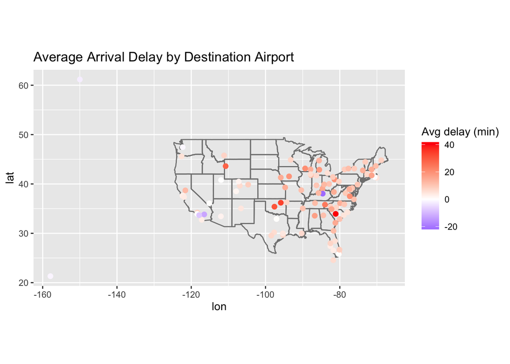

```r
# This requires the maps package.
library(maps)

flight_avg_delay |>
  ggplot(aes(lon, lat, color = avg_delay)) +
  annotation_borders("state") +
  geom_point(size = 2) +
  coord_quickmap() +
  scale_color_gradient2(low = "blue", mid = "white", high = "red",
                        midpoint = 0) +
  labs(title = "Average Arrival Delay by Destination Airport",
       color  = "Avg delay (min)")
```

Which regions of the country have the worst average arrival delays?

```r
flight_avg_delay |>
  arrange(desc(avg_delay)) |>
  slice_head(n = 4)
```

```
# A tibble: 4 × 9
  dest  avg_delay name                    lat    lon   alt    tz dst   tzone
  <chr>     <dbl> <chr>                 <dbl>  <dbl> <dbl> <dbl> <chr> <chr>
1 CAE        41.8 Columbia Metropolitan  33.9  -81.1   236    -5 A     America/…
2 TUL        33.7 Tulsa Intl             36.2  -95.9   677    -6 A     America/…
3 OKC        30.6 Will Rogers World      35.4  -97.6  1295    -6 A     America/…
4 JAC        28.1 Jackson Hole Airport   43.6 -111.   6451    -7 A     America/…
```

Well, the worst flight delay in the country was right here in Columbia!!

**Exercise 4**

Build a single polished figure that answers this question: **How does the 10-year coronary heart disease rate in the Framingham cohort vary by age group, sex, and hypertension status?**

Steps:

1. Create an age group variable using `case_when()`: “40–44”, “45–49”, “50–54”, “55–59”, “60–64”, “65+” (or similar grouping of your choosing). Make it a factor with levels in the right order.

```r
framingham <- framingham |>
  mutate(
    age_group = factor(case_when(
      age < 45 ~ "40-44",
      age < 50 ~ "45-49",
      age < 55 ~ "50-54",
      age < 60 ~ "55-59",
      age < 65 ~ "60-64",
      age >= 65 ~ "65+"
    ))
  )
# Check the ordering of the factor
framingham$age_group[1:5]
```

```
[1] 40-44 45-49 45-49 60-64 45-49
Levels: 40-44 45-49 50-54 55-59 60-64 65+
```

2. Compute the CHD rate (proportion with `TenYearCHD == "Yes"`) for each combination of age group, sex, and hypertension status using `group_by()` and `summarize()`. Keep only groups with at least 20 participants.

```r
avg_CHD_data <- framingham |>
  group_by(age_group, male, prevalentHyp) |>
  summarise(
    N = n(),
    avg_CHD = mean(TenYearCHD == "Yes")
  ) |>
  filter(N >=20)
```

3. Plot the result. A grouped bar chart (`geom_col()` with `position = "dodge"`) or a line plot (`geom_line()` + `geom_point()`) with age group on the x-axis works well here. Color by hypertension status, facet by sex.

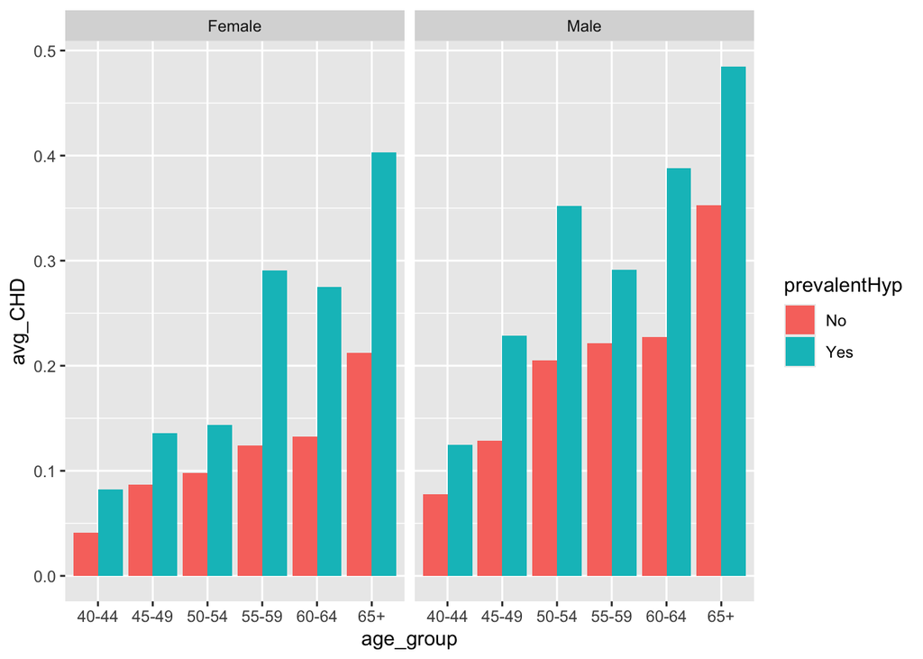

```r
ggplot(avg_CHD_data, aes(x = age_group, y = avg_CHD, fill = prevalentHyp)) +
  geom_col(position = "dodge") +
  facet_wrap(~male)
```

4. Add a full set of labels, a meaningful color palette, and a clean theme.

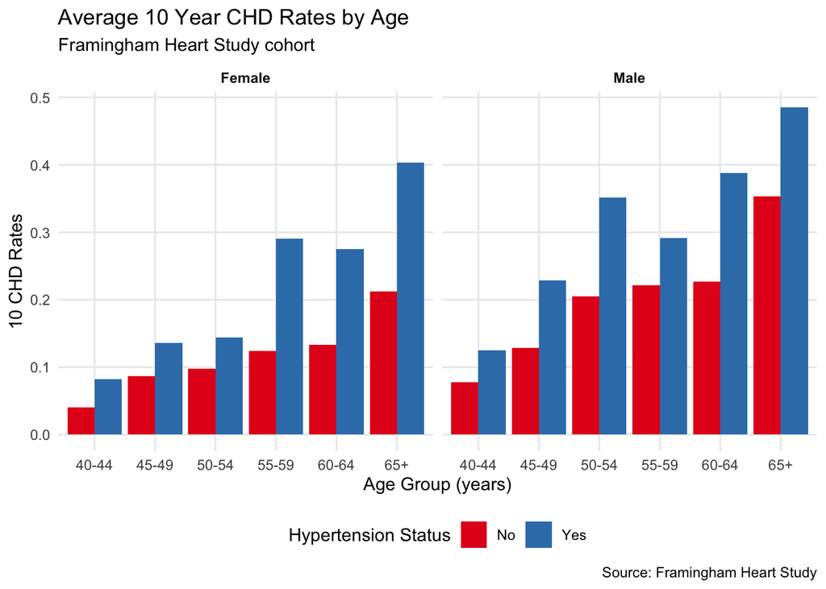

```r
ggplot(avg_CHD_data, aes(x = age_group, y = avg_CHD, fill = prevalentHyp)) +
  geom_col(position = "dodge") +
  facet_wrap(~male) +
  theme_minimal() +
  scale_fill_brewer(palette = "Set1") +
  theme(
    legend.position  = "bottom",
    panel.grid.minor = element_blank(),
    strip.text       = element_text(face = "bold")
  ) +
  labs(
    title    = "Average 10 Year CHD Rates by Age",
    subtitle = "Framingham Heart Study cohort",
    caption  = "Source: Framingham Heart Study",
    x        = "Age Group (years)",
    y        = "10 CHD Rates",
    fill     = "Hypertension Status"
  )
```

5. Save the figure with `ggsave()` at 300 dpi.

```r
ggsave("chd_vs_age.png", width = 7, height = 5, dpi = 300)
ggsave("chd_vs_age.pdf", width = 7, height = 5)
```

6. Write a 3–4 sentence caption summarizing the main findings as if this were going into a manuscript.

First, the CHD rates increase by age group for males and females. Overall, the CHD rates for males are higher than they are for females. Lastly, it appears that the different in CHD rates between those with and without hypertension, is different for males and females. For females, having hypertension is a bigger risk factor for CHD than for males (especially for the older age groups).